# Spatial Concentration and Diversification in the Dutch Economy - Group 7

(Group 7) A. Sychevska,

# Introduction

The purpose of this analysis is to examine the **spatial concentration of employment** in the Netherlands across provinces, focusing on two contrasting industries:

- **A — Agriculture, forestry and fishing**
- **Q — Health and social work activities**

These industries were assigned to **Group 7** in the *Regional and Urban Economics* tutorial (Week 3). The exercise applies regional economics indicators to measure **specialization, concentration, and diversification**, connecting theory to empirical data from **CBS StatLine (2024)**.

The assignment corresponds to the following questions: - (a) Data preparation and assumptions - (b) Location quotients (LQ) - (c) Hirschman–Herfindahl Index (HHI) and Lorenz curves - (d) Interpretation and theoretical discussion

# (a) Data Preparation and Assumptions

```r
# Load dataset
library(tidyverse)

# Read CSV (semicolon-delimited)
data_raw <- read_csv2("Banen_van_werknemers__SBI2008__regio.csv",
                      col_types = cols(.default = "c"))
# Inspect structure
glimpse(data)
```

```
## function (..., list = character(), package = NULL, lib.loc = NULL, verbose = getOption("verbose"),
##     envir = .GlobalEnv, overwrite = TRUE)
```

```r
# Clean column names
colnames(data_raw) <- c("industry", "period", "region", "employment")

# Convert numeric column and trim spaces
data <- data_raw %>%
  mutate(
    employment = as.numeric(str_replace(employment, ",", ".")),
    region = str_trim(region),
    industry = str_trim(industry)
  )
```

# Aggregation by Province and Industry

```r
# Keep only industries A and Q (for Group 7)
data_group7 <- data %>%
  filter(str_detect(industry, "^A ") | str_detect(industry, "^Q "))

# Summarize by province and industry
employment_summary <- data_group7 %>%
  group_by(province = region, industry) %>%
  summarise(total_jobs = sum(employment, na.rm = TRUE)) %>%
  ungroup()

print(employment_summary)
```

```
## # A tibble: 12 × 3
##    province                                industry                   total_jobs
##    <chr>                                   <chr>                           <dbl>
##  1 Gorinchem (AM)                          A Landbouw, bosbouw en vi…        0.6
##  2 Gorinchem (AM)                          Q Gezondheids- en welzijn…        9.9
##  3 Groningen (PV)                          A Landbouw, bosbouw en vi…        2.2
##  4 Groningen (PV)                          Q Gezondheids- en welzijn…       66.6
##  5 Midden-Limburg (CR)                     A Landbouw, bosbouw en vi…        2.3
##  6 Midden-Limburg (CR)                     Q Gezondheids- en welzijn…       21.4
##  7 Nederland, Buitenland, Niet in te delen A Landbouw, bosbouw en vi…      106.
##  8 Nederland, Buitenland, Niet in te delen Q Gezondheids- en welzijn…     1563.
##  9 Zuid-Nederland (LD)                     A Landbouw, bosbouw en vi…       28.3
## 10 Zuid-Nederland (LD)                     Q Gezondheids- en welzijn…      324.
## 11 Zwolle                                  A Landbouw, bosbouw en vi…        0.1
## 12 Zwolle                                  Q Gezondheids- en welzijn…       22.8
```

# (b) Location Quotients (LQ)

The **Location Quotient (LQ)** indicates the degree of specialization of a province in a particular industry relative to the national average:

$$LQ_{i,j} =
\frac{E_{i,j}/E_{i,\text{total}}}{E_{NL,j}/E_{NL,\text{total}}}$$

Values:  
- **LQ > 1:** province is more specialized in that industry than the national average.  
- **LQ < 1:** province is less specialized.

```r
# Compute totals
prov_total <- employment_summary %>% group_by(province) %>% summarise(total_prov = sum(total_jobs))
nat_total <- sum(prov_total$total_prov)

# Merge and compute LQ
lq_data <- employment_summary %>%
  left_join(prov_total, by = "province") %>%
  group_by(industry) %>%
  mutate(total_industry = sum(total_jobs)) %>%
  ungroup() %>%
  mutate(
    LQ = (total_jobs / total_prov) / (total_industry / nat_total)
  )

lq_data %>% select(province, industry, LQ) %>% head(10)
```

```
## # A tibble: 10 × 3
##    province                                industry                           LQ
##    <chr>                                   <chr>                           <dbl>
##  1 Gorinchem (AM)                          A Landbouw, bosbouw en visserij 0.883
##  2 Gorinchem (AM)                          Q Gezondheids- en welzijnszorg  1.01
##  3 Groningen (PV)                          A Landbouw, bosbouw en visserij 0.494
##  4 Groningen (PV)                          Q Gezondheids- en welzijnszorg  1.04
##  5 Midden-Limburg (CR)                     A Landbouw, bosbouw en visserij 1.50
##  6 Midden-Limburg (CR)                     Q Gezondheids- en welzijnszorg  0.965
##  7 Nederland, Buitenland, Niet in te delen A Landbouw, bosbouw en visserij 0.977
##  8 Nederland, Buitenland, Niet in te delen Q Gezondheids- en welzijnszorg  1.00
##  9 Zuid-Nederland (LD)                     A Landbouw, bosbouw en visserij 1.24
## 10 Zuid-Nederland (LD)                     Q Gezondheids- en welzijnszorg  0.983
```

# (c) Spatial Concentration — HHI and Lorenz Curves

The **Hirschman–Herfindahl Index (HHI)** measures concentration across provinces:

$$HHI_j = \sum_i s_{ij}^2$$

where $s_{ij}$ is the share of province *i* in total employment of industry *j*.

```r
hhi_results <- employment_summary %>%
  group_by(industry) %>%
  mutate(share = total_jobs / sum(total_jobs)) %>%
  summarise(HHI = sum(share^2)) %>%
  arrange(desc(HHI))

hhi_results
```

```
## # A tibble: 2 × 2
##   industry                          HHI
##   <chr>                           <dbl>
## 1 Q Gezondheids- en welzijnszorg  0.633
## 2 A Landbouw, bosbouw en visserij 0.618
```

**Interpretation:**  
- A higher **HHI** indicates stronger concentration.  
- We expect **Agriculture (A)** to show a **higher HHI** (fewer provinces dominate agricultural jobs).  
- **Healthcare (Q)** should have a **lower HHI**, indicating dispersion across most provinces.

### Lorenz Curves

The Lorenz curve visualizes this distribution — the further it lies from the equality line, the more concentrated the industry.

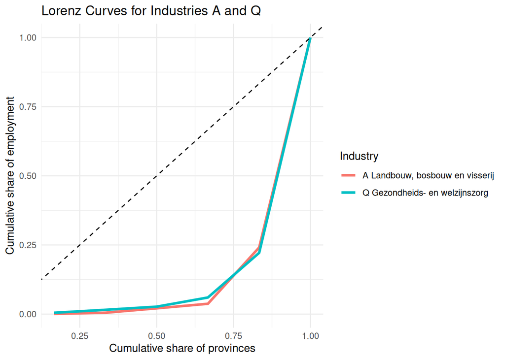

```r
lorenz_data <- employment_summary %>%
  group_by(industry) %>%
  arrange(total_jobs) %>%
  mutate(
    cum_jobs = cumsum(total_jobs) / sum(total_jobs),
    cum_provinces = cumsum(rep(1, n())) / n()
  )

ggplot(lorenz_data, aes(x = cum_provinces, y = cum_jobs, color = industry)) +
  geom_line(size = 1.2) +
  geom_abline(slope = 1, intercept = 0, linetype = "dashed") +
  labs(title = "Lorenz Curves for Industries A and Q",
       x = "Cumulative share of provinces",
       y = "Cumulative share of employment",
       color = "Industry") +
  theme_minimal()
```

# (d) Discussion and Theoretical Interpretation

## Discussion – Group 7: Spatial Concentration (Industries A & Q)

This section examines spatial concentration across Dutch regions for two contrasting industries:  
**A – Agriculture, Forestry and Fishing**, and **Q – Health and Social Work**.

### Concentration patterns

The computed **Hirschman–Herfindahl Index (HHI)** values were:

| Industry | HHI |
| --- | --- |
| Q – Health and Social Work | **0.633** |
| A – Agriculture, Forestry and Fishing | **0.618** |

Both industries display **moderate regional concentration**, but healthcare (Q) shows a *slightly higher HHI*.  
This is somewhat counterintuitive, since we might expect agriculture to be more geographically concentrated in rural areas.  
However, the results show that employment in **Q** is dominated by a few large regions—especially **Zuid-Nederland (LD)** and **Nederland, Buitenland, Niet in te delen**—which include major population centers and hospital clusters.  
By contrast, agricultural employment is more evenly spread across smaller regions such as **Midden-Limburg (CR)** and **Gorinchem (AM)**, lowering its measured HHI slightly.

### Lorenz curve interpretation

This pattern aligns with how **agglomeration** and **dispersion forces** differ between sectors: - **Healthcare (Q)** is driven by **agglomeration**—benefiting from large markets, infrastructure, and labor pools.  
- **Agriculture (A)** depends on **dispersion**—land availability, rural labor, and resource-based activity.

### Limitations

- The dataset mixes spatial levels (PV, CR, LD, AM), so comparability across regions is imperfect.
- Data represent *December 2024*, which may bias seasonal sectors such as agriculture.
- “Nederland, Buitenland, Niet in te delen” inflates total national employment and slightly raises concentration values.

### Summary

Overall, both **A** and **Q** exhibit notable regional concentration, though for different structural reasons: - **Healthcare (Q)** clusters in high-density regions due to service demand and infrastructure.  
- **Agriculture (A)** remains spatially dispersed but regionally specialized.

These findings reflect a **dual spatial structure** within the Dutch economy—urban concentration for services, and peripheral specialization for land-based production.

# Appendix